# Modal split of inland passenger transport in the EU

Eurostat tran_hv_psmod

Author

Mohd Zamin Quadri

Published

October 19, 2026

## What this is

A worked example of reading an official statistical API in R and reporting what it says, with every number in the prose computed from the data rather than typed in.

The dataset is Eurostat’s **modal split of inland passenger transport**: for each country and year, the share of inland passenger-kilometres travelled by passenger car, by train, and by motor coach, bus or trolley bus. The three shares sum to 100% by construction, so this measures *how* people travel rather than *how much*.

The raw response is committed at `data/raw/tran_hv_psmod.json` with its SHA-256 and retrieval date in `data/raw/PROVENANCE.md`, so the report renders offline and the figures cannot drift from the numbers underneath them.

The snapshot covers **35 countries** and the years **1990 to 2024**, though coverage is uneven: not every country reports every year, and the series are sparse rather than rectangular.

## How complete is the data?

Worth establishing before drawing any trend, because a line chart over a sparse series invites the reader to interpolate through years nobody measured.

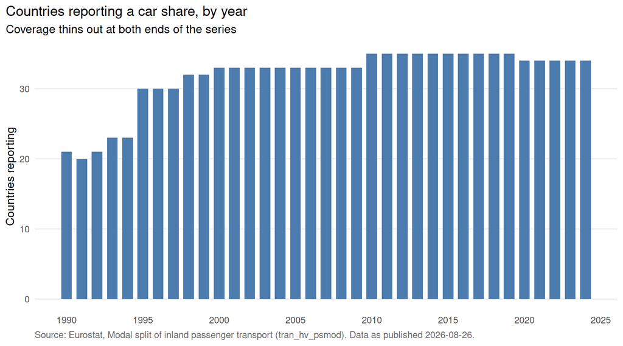

Reporting completeness by year. Each cell is one country-year for passenger cars.

```r
cars <- countries[countries$vehicle == "CAR", ]

# as.data.frame(table(...)) makes `year` a factor whatever stringsAsFactors
# says, and as.integer() on a factor returns the level index rather than the
# label. Going via as.character() is what keeps these actual years.
per_year <- as.data.frame(table(year = cars$year), stringsAsFactors = FALSE)
per_year$year <- as.integer(as.character(per_year$year))
names(per_year)[2] <- "n_countries"

ggplot(per_year, aes(x = year, y = n_countries)) +
  geom_col(fill = MODE_COLOURS[["Passenger cars"]], width = 0.7) +
  scale_x_continuous(breaks = seq(1990, 2025, 5)) +
  labs(
    title = "Countries reporting a car share, by year",
    subtitle = "Coverage thins out at both ends of the series",
    x = NULL, y = "Countries reporting",
    caption = EUROSTAT_CAPTION
  ) +
  theme_report()
```

Coverage peaks at **35 countries in 2010**. The most recent year with at least 90% of that peak is **2024**, which is the year used below wherever a single-year comparison is made. Picking the latest year present instead would compare a handful of early reporters against each other.

## The long-run picture

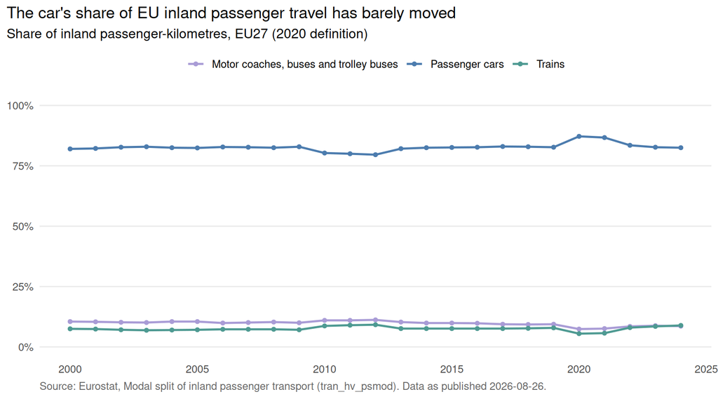

EU-level modal split over time, using the EU27_2020 aggregate.

```r
eu <- modal[modal$geo == "EU27_2020", ]

ggplot(eu, aes(x = year, y = value, colour = vehicle_label)) +
  geom_line(linewidth = 0.9) +
  geom_point(size = 1.4) +
  scale_colour_manual(values = MODE_COLOURS) +
  scale_y_continuous(limits = c(0, 100), labels = function(x) paste0(x, "%")) +
  labs(
    title = "The car's share of EU inland passenger travel has barely moved",
    subtitle = "Share of inland passenger-kilometres, EU27 (2020 definition)",
    x = NULL, y = NULL,
    caption = EUROSTAT_CAPTION
  ) +
  theme_report()
```

The car share stood at **82.0%** in 2000 and **82.5%** in 2024, a change of **+0.5 percentage points** across 24 years. Whatever has changed in European transport policy over that period, it has not changed what share of distance is driven.

## Who depends on cars most?

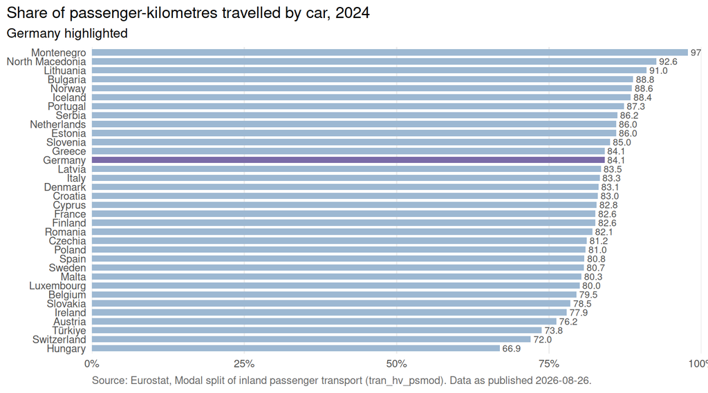

Car share by country in the reference year, highest first.

```r
ref <- cars[cars$year == latest_full, ]
ref <- ref[order(ref$value), ]
ref$geo_label <- factor(ref$geo_label, levels = ref$geo_label)

ggplot(ref, aes(x = value, y = geo_label)) +
  geom_col(
    aes(fill = geo == "DE"),
    width = 0.7, show.legend = FALSE
  ) +
  scale_fill_manual(values = c("TRUE" = "#7A6BA8", "FALSE" = "#9DB8D2")) +
  geom_text(
    aes(label = sprintf("%.1f", value)),
    hjust = -0.15, size = 3, colour = "grey30"
  ) +
  scale_x_continuous(
    limits = c(0, 100), labels = function(x) paste0(x, "%"), expand = c(0, 0)
  ) +
  labs(
    title = paste0("Share of passenger-kilometres travelled by car, ", latest_full),
    subtitle = "Germany highlighted",
    x = NULL, y = NULL,
    caption = EUROSTAT_CAPTION
  ) +
  theme_report() +
  theme(panel.grid.major.y = element_blank(), panel.grid.major.x = element_line())
```

## Where rail actually gained

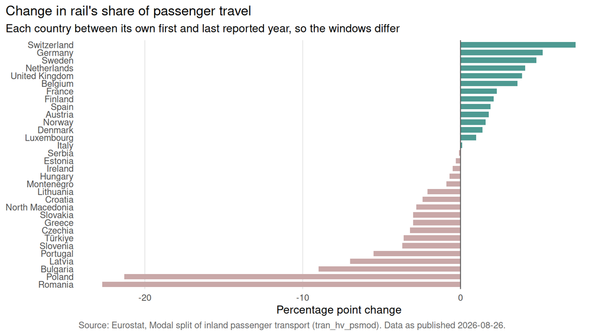

Change in rail share between each country’s first and last reported year.

```r
trains <- countries[countries$vehicle == "TRN", ]

# Each country's own first and last reported year, not a fixed window. A fixed
# window would drop every country whose series starts late, which is most of
# the 2004 and 2007 accession states.
change <- do.call(rbind, lapply(split(trains, trains$geo), function(g) {
  g <- g[order(g$year), ]
  if (nrow(g) < 2) return(NULL)
  data.frame(
    geo = g$geo[1],
    geo_label = g$geo_label[1],
    from_year = g$year[1],
    to_year = g$year[nrow(g)],
    change = g$value[nrow(g)] - g$value[1],
    stringsAsFactors = FALSE
  )
}))

change <- change[order(change$change), ]
change$geo_label <- factor(change$geo_label, levels = change$geo_label)

ggplot(change, aes(x = change, y = geo_label, fill = change > 0)) +
  geom_col(width = 0.7, show.legend = FALSE) +
  scale_fill_manual(values = c("TRUE" = "#4E9A92", "FALSE" = "#C9A8A8")) +
  geom_vline(xintercept = 0, colour = "grey30", linewidth = 0.4) +
  labs(
    title = "Change in rail's share of passenger travel",
    subtitle = "Each country between its own first and last reported year, so the windows differ",
    x = "Percentage point change", y = NULL,
    caption = EUROSTAT_CAPTION
  ) +
  theme_report() +
  theme(panel.grid.major.y = element_blank(), panel.grid.major.x = element_line())
```

**14 of 32 countries** increased rail’s share and **18** reduced it. The largest gain is **Switzerland**, up **7.3 percentage points** between 1990 and 2024.

Each bar covers a different span of years, which is stated on the chart rather than hidden: a country reporting only since 2010 is not comparable with one reporting since 1990, and forcing a common window would have discarded most of the newer member states entirely.

## What this does not show

- **Shares, not volumes.** A falling car share is consistent with more driving, if rail grew faster. Nothing here measures total distance travelled.
- **Inland transport only.** Air and sea are excluded by the dataset’s own definition, so this is not a complete picture of how people travel between countries.
- **Unequal windows.** Countries enter the series at different dates. Every comparison above either uses a single stated year or labels the span it covers.
- **No causal claim.** The report describes what the series contains. It does not attribute any change to any policy.